# Pós-graduação em Ciências Veterinárias (IV/UFRRJ)

Lista 2: Modelo de Regressão Linear Múltipla - MRLM

Adriana Andrade Wagner Tassinari

2021

### **Questão:** O banco de dados **pig_adg.xlsx** ([link](https://drive.google.com/file/d/1t2pg-0SChcSqtr1eGRDXLkw0VsX_BsXm/view?usp=sharing)), é constituido de dados provenientes de um inquérito sobre o desempenho de crescimento em matadouros de suínos em fazendas da Ilha do Príncipe Eduardo, Canadá. Os dados foram coletados para estudar as inter-relações entre doenças respiratórias (rinite atrófica e pneumonia enzoótica), níveis de ascarídeos e ganho de peso diário.

| Variável | Descrição | Códigos/Unidades |
| --- | --- | --- |
| **farm** | Id fazenda | - |
| **pig** | Id animal | - |
| **sex** | Sexo do animal | 0: Fêmea / 1: Macho |
| **dmt** | Dias para o mercado (ou seja, do nascimento até o abate) | dias |
| **adg** | Ganho de peso médio diário | gramas |
| **mm** | Medição do comprimento do focinho | mm |
| **ar** | Escore da rinite atrófica | 0 a 5 |
| **lu** | Escore para pneumonia enzoótica | 0: Negativa / 1: Suave / 2: Moderada / 3: Severa |
| **pn** | Pneumonia (**lu > 0**) | 0/1 |
| **epg5** | Contagem de ovos de nematóides gastrointestinais fecais na hora do abate | Ovos / 5 gramas |
| **worms** | Contagem de nematóides no intestino delgado na hora do abate | Contagem |
| **li** | Escore do fígado (com base no número de parasitas induzido ‘manchas brancas’) | 0: Negativa / 1: Suave / 2: Severo |
| **ar2** | Rinite atrófica severa (**ar > 4**) | 0/1 |

```r
# Importando os dados
library(readxl)
banco <- read_excel("pig_adg.xlsx")

# Trasformando as variáveis categoricas em fator
banco$sex <- factor(banco$sex, labels = c("Femea", "Macho"))
banco$lu <- factor(banco$lu, labels = c("Negativa", "Suave", "Moderada", "Severa"))
banco$pn <- factor(banco$pn, labels = c("Positivo", "Negativo"))
banco$li <- factor(banco$li, labels = c("Negativa", "Suave", "Severa"))
banco$ar2 <- factor(banco$ar2, labels = c("Positivo", "Negativo"))
```

Baseado nesse banco de dados e utilizando a variável **adg** (ganho de peso médio diário em gramas) como variável dependente ($Y$), faça:

### 1. Uma breve análise exploratória de dados (análise univariada). *Sugestão: Tente focar na variável dependente e nas variáveis que serão potenciais preditoras dessa variável $Y$*;

```r
# Explorando o banco
library(skimr)
skim(banco)
```

Data summary

| Name | banco |
| --- | --- |
| Number of rows | 341 |
| Number of columns | 13 |
| _______________________ |  |
| Column type frequency: |  |
| factor | 5 |
| numeric | 8 |
| ________________________ |  |
| Group variables | None |

**Variable type: factor**

| skim_variable | n_missing | complete_rate | ordered | n_unique | top_counts |
| --- | --- | --- | --- | --- | --- |
| sex | 0 | 1 | FALSE | 2 | Fem: 172, Mac: 169 |
| lu | 0 | 1 | FALSE | 4 | Neg: 155, Sua: 138, Mod: 31, Sev: 17 |
| pn | 0 | 1 | FALSE | 2 | Neg: 186, Pos: 155 |
| li | 0 | 1 | FALSE | 3 | Sua: 142, Sev: 137, Neg: 62 |
| ar2 | 0 | 1 | FALSE | 2 | Pos: 307, Neg: 34 |

**Variable type: numeric**

| skim_variable | n_missing | complete_rate | mean | sd | p0 | p25 | p50 | p75 | p100 | hist |
| --- | --- | --- | --- | --- | --- | --- | --- | --- | --- | --- |
| farm | 0 | 1 | 7.77 | 4.37 | 1 | 4.0 | 8.0 | 11 | 15 | ▇▇▇▆▇ |
| pig | 0 | 1 | 171.00 | 98.58 | 1 | 86.0 | 171.0 | 256 | 341 | ▇▇▇▇▇ |
| dtm | 0 | 1 | 189.41 | 22.35 | 141 | 175.0 | 188.0 | 203 | 254 | ▃▇▇▃▁ |
| adg | 0 | 1 | 519.40 | 70.97 | 317 | 469.0 | 519.0 | 568 | 707 | ▁▅▇▆▁ |
| mm | 0 | 1 | 9.50 | 4.75 | 0 | 6.0 | 8.0 | 10 | 24 | ▁▇▃▁▂ |
| ar | 0 | 1 | 1.65 | 1.41 | 0 | 0.5 | 1.5 | 2 | 5 | ▇▅▂▁▂ |
| epg5 | 0 | 1 | 78.63 | 294.04 | 0 | 0.0 | 0.0 | 0 | 3025 | ▇▁▁▁▁ |
| worms | 0 | 1 | 3.37 | 9.88 | 0 | 0.0 | 0.0 | 2 | 72 | ▇▁▁▁▁ |

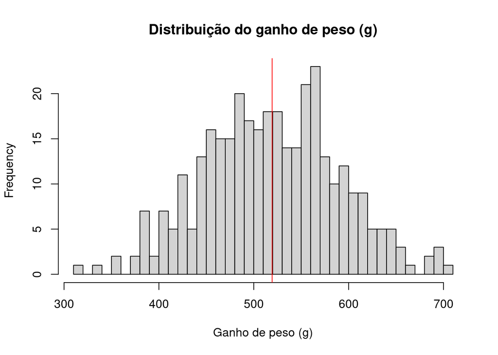

```r
# Analisando a variável dependente
hist(banco$adg, nclass=50,  xlab="Ganho de peso (g)", main="Distribuição do ganho de peso (g)")
abline(v=mean(banco$adg, na.rm=T), col="red")
```

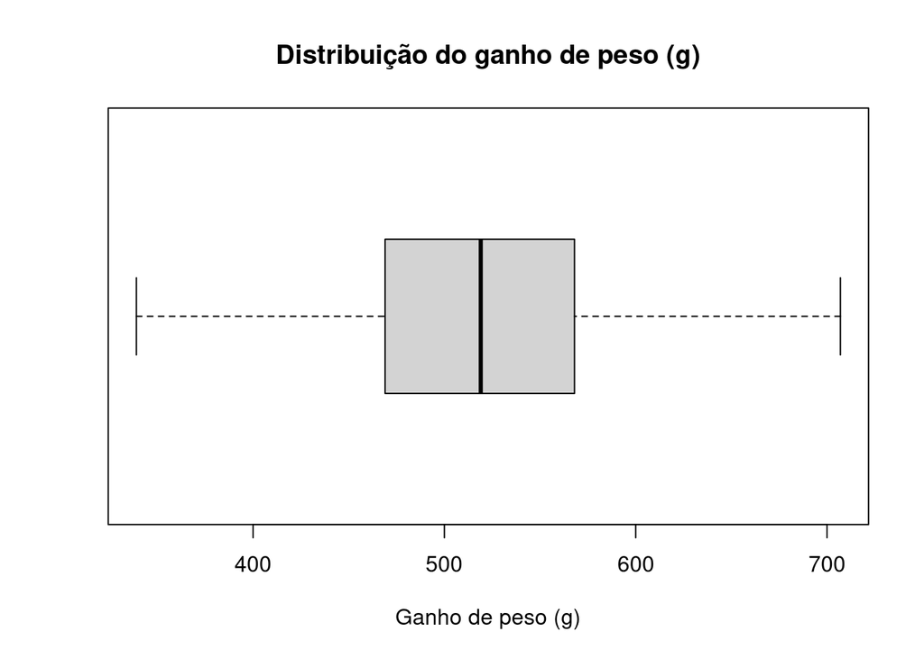

```r
boxplot(banco$adg, xlab="Ganho de peso (g)", main="Distribuição do ganho de peso (g)", horizontal=T, outline = FALSE)
```

```r
summary(banco$adg)
```

```
##    Min. 1st Qu.  Median    Mean 3rd Qu.    Max.
##   317.0   469.0   519.0   519.4   568.0   707.0
```

### 2. Verifique a correlação entre as variáveis dependentes e as independentes (análise bivariada). *Sugestão: Fazer diagramas de disperção entre as variáveis quantitativas e a matriz de correlação entre todas as variáveis*;

```r
names(banco)
```

```
##  [1] "farm"  "pig"   "sex"   "dtm"   "adg"   "mm"    "ar"    "lu"    "pn"
## [10] "epg5"  "worms" "li"    "ar2"
```

```r
# Matriz de correlação das vars quantitativas
cor(banco[c(4,5,6, 7, 10, 11)])
```

```
##              dtm        adg          mm          ar        epg5       worms
## dtm    1.0000000 -0.8683469  0.27570909  0.28095337 -0.24702479 -0.27045236
## adg   -0.8683469  1.0000000 -0.27413776 -0.27106924  0.19801178  0.24722223
## mm     0.2757091 -0.2741378  1.00000000  0.95441463 -0.07326293 -0.05195651
## ar     0.2809534 -0.2710692  0.95441463  1.00000000 -0.07933018 -0.07362835
## epg5  -0.2470248  0.1980118 -0.07326293 -0.07933018  1.00000000  0.82714849
## worms -0.2704524  0.2472222 -0.05195651 -0.07362835  0.82714849  1.00000000
```

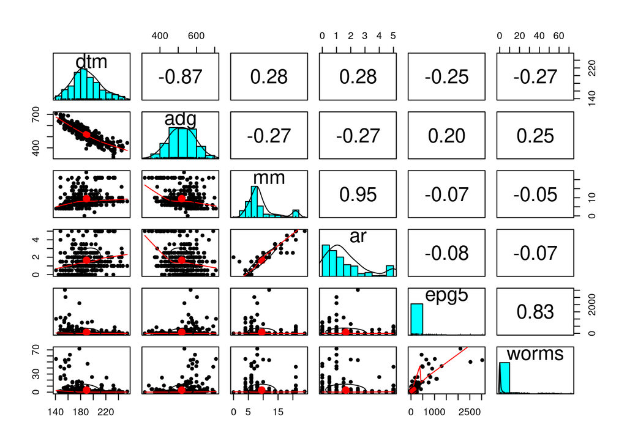

```r
# Forma gráfica
library(psych)
pairs.panels(banco[c(4,5,6, 7, 10, 11)])
```

```r
# Correlação de todas as variáveis do banco
library(polycor)
hetcor(banco[-1]) # retirando apenas a var farm e pig
```

```
##
## Two-Step Estimates
##
## Correlations/Type of Correlation:
##            pig        sex        dtm        adg         mm         ar
## pig          1 Polyserial    Pearson    Pearson    Pearson    Pearson
## sex    0.01033          1 Polyserial Polyserial Polyserial Polyserial
## dtm     0.2155    -0.2518          1    Pearson    Pearson    Pearson
## adg    -0.2759     0.2353    -0.8683          1    Pearson    Pearson
## mm    -0.02733   -0.01594     0.2757    -0.2741          1    Pearson
## ar    -0.01181   -0.02101      0.281    -0.2711     0.9544          1
## lu     -0.2637    0.06739    0.02584   -0.08144     0.1141     0.1289
## pn     -0.2527  -0.003372     0.1545    -0.2169     0.1464     0.1626
## epg5    0.1742   -0.01892     -0.247      0.198   -0.07326   -0.07933
## worms    0.195   0.008271    -0.2705     0.2472   -0.05196   -0.07363
## li     0.07146   -0.07969    -0.1964     0.1264   -0.00987   -0.02436
## ar2     0.1181   -0.03571     0.4213    -0.4463       <NA>     0.9382
##               lu         pn       epg5      worms         li        ar2
## pig   Polyserial Polyserial    Pearson    Pearson Polyserial Polyserial
## sex   Polychoric Polychoric Polyserial Polyserial Polychoric Polychoric
## dtm   Polyserial Polyserial    Pearson    Pearson Polyserial Polyserial
## adg   Polyserial Polyserial    Pearson    Pearson Polyserial Polyserial
## mm    Polyserial Polyserial    Pearson    Pearson Polyserial Polyserial
## ar    Polyserial Polyserial    Pearson    Pearson Polyserial Polyserial
## lu             1 Polychoric Polyserial Polyserial Polychoric Polychoric
## pn          <NA>          1 Polyserial Polyserial Polychoric Polychoric
## epg5     0.03138   -0.02638          1    Pearson Polyserial Polyserial
## worms   -0.01615    -0.0815     0.8271          1 Polyserial Polyserial
## li     -0.002995    0.02097    0.09877     0.2044          1 Polychoric
## ar2      0.01974     0.1046     -0.111   -0.01401     0.0347          1
##
## Standard Errors:
##           pig     sex     dtm     adg       mm      ar      lu      pn    epg5
## pig
## sex   0.06797
## dtm   0.05171 0.06436
## adg   0.05011 0.06465 0.01339
## mm    0.05418 0.06795 0.05012 0.05016
## ar    0.05421 0.06795 0.04996 0.05026 0.004852
## lu    0.05597 0.07619  0.0617 0.06067  0.05936 0.05906
```

[output cut: 33 more lines]

```
## li     0.0001782     0.5348    0.02747     0.6708  3.333e-07   6.08e-08
## ar2    0.0004363       <NA>    0.01068     0.8378          0        NaN
##               lu         pn       epg5      worms      li
## pig
## sex
## dtm
## adg
## mm
## ar
## lu
## pn             0
## epg5   6.26e-131 1.747e-133
## worms 7.621e-115 1.212e-117 5.303e-204
## li        0.7811     0.1756  3.96e-130  3.08e-117
## ar2      0.01113       <NA> 3.066e-132 7.305e-118 0.04529
```

### 3. Ajuste modelos de regressão linear simples para verificar qual (is) variável(is) será/serão significativas (análise bivariada). *Sugestão: Levar em consideração $\alpha = 20\%$ para escolher quais as variáveis irão compor o modelo de regressão linear múltipla*;

```r
m1 <- lm(adg ~ sex, banco)
m2 <- lm(adg ~ dtm, banco)
m3 <- lm(adg ~ mm, banco)
m4 <- lm(adg ~ ar, banco)
m5 <- lm(adg ~ lu, banco)
m6 <- lm(adg ~ pn, banco)
m7 <- lm(adg ~ epg5, banco)
m8 <- lm(adg ~ worms, banco)
m9 <- lm(adg ~ li, banco)
m10 <- lm(adg ~ ar2, banco)

summary(m1)
```

```
##
## Call:
## lm(formula = adg ~ sex, data = banco)
##
## Residuals:
##      Min       1Q   Median       3Q      Max
## -193.751  -48.279   -2.279   47.721  174.249
##
## Coefficients:
##             Estimate Std. Error t value Pr(>|t|)
## (Intercept)  506.279      5.324  95.097  < 2e-16 ***
## sexMacho      26.472      7.562   3.501 0.000526 ***
## ---
## Signif. codes:  0 '***' 0.001 '**' 0.01 '*' 0.05 '.' 0.1 ' ' 1
##
## Residual standard error: 69.82 on 339 degrees of freedom
## Multiple R-squared:  0.03489,    Adjusted R-squared:  0.03204
## F-statistic: 12.25 on 1 and 339 DF,  p-value: 0.0005264
```

```r
summary(m2)
```

```
##
## Call:
## lm(formula = adg ~ dtm, data = banco)
##
## Residuals:
##      Min       1Q   Median       3Q      Max
## -128.531  -24.235    1.249   23.752  102.729
##
## Coefficients:
##               Estimate Std. Error t value Pr(>|t|)
## (Intercept) 1041.76503   16.31619   63.85   <2e-16 ***
## dtm           -2.75785    0.08555  -32.24   <2e-16 ***
## ---
## Signif. codes:  0 '***' 0.001 '**' 0.01 '*' 0.05 '.' 0.1 ' ' 1
##
## Residual standard error: 35.25 on 339 degrees of freedom
## Multiple R-squared:  0.754,  Adjusted R-squared:  0.7533
## F-statistic:  1039 on 1 and 339 DF,  p-value: < 2.2e-16
```

```r
summary(m3)
```

```
##
## Call:
## lm(formula = adg ~ mm, data = banco)
##
## Residuals:
##      Min       1Q   Median       3Q      Max
## -155.242  -52.543   -3.743   48.457  219.758
##
## Coefficients:
##             Estimate Std. Error t value Pr(>|t|)
## (Intercept) 558.3432     8.2920  67.335  < 2e-16 ***
## mm           -4.1000     0.7812  -5.248 2.71e-07 ***
## ---
## Signif. codes:  0 '***' 0.001 '**' 0.01 '*' 0.05 '.' 0.1 ' ' 1
##
## Residual standard error: 68.35 on 339 degrees of freedom
## Multiple R-squared:  0.07515,    Adjusted R-squared:  0.07242
## F-statistic: 27.55 on 1 and 339 DF,  p-value: 2.71e-07
```

```r
summary(m4)
```

```
##
## Call:
## lm(formula = adg ~ ar, data = banco)
##
## Residuals:
##      Min       1Q   Median       3Q      Max
## -156.805  -54.310    0.064   49.755  218.195
##
## Coefficients:
##             Estimate Std. Error t value Pr(>|t|)
## (Intercept)  541.936      5.711  94.891  < 2e-16 ***
## ar           -13.626      2.628  -5.185 3.72e-07 ***
## ---
## Signif. codes:  0 '***' 0.001 '**' 0.01 '*' 0.05 '.' 0.1 ' ' 1
##
## Residual standard error: 68.41 on 339 degrees of freedom
## Multiple R-squared:  0.07348,    Adjusted R-squared:  0.07075
## F-statistic: 26.88 on 1 and 339 DF,  p-value: 3.721e-07
```

```r
summary(m5)
```

```
##
## Call:
## lm(formula = adg ~ lu, data = banco)
##
## Residuals:
##      Min       1Q   Median       3Q      Max
## -178.565  -45.565   -0.774   45.529  174.226
##
## Coefficients:
##             Estimate Std. Error t value Pr(>|t|)
## (Intercept)  532.774      5.473  97.345  < 2e-16 ***
## luSuave      -37.209      7.975  -4.666 4.44e-06 ***
## luModerada    23.065     13.406   1.720   0.0863 .
## luSevera      -8.304     17.409  -0.477   0.6337
## ---
## Signif. codes:  0 '***' 0.001 '**' 0.01 '*' 0.05 '.' 0.1 ' ' 1
##
## Residual standard error: 68.14 on 337 degrees of freedom
## Multiple R-squared:  0.08627,    Adjusted R-squared:  0.07813
## F-statistic: 10.61 on 3 and 337 DF,  p-value: 1.111e-06
```

```r
summary(m6)
```

```
##
## Call:
## lm(formula = adg ~ pn, data = banco)
##
## Residuals:
##      Min       1Q   Median       3Q      Max
## -191.253  -48.253    1.226   50.226  179.747
##
## Coefficients:
##             Estimate Std. Error t value Pr(>|t|)
## (Intercept)  532.774      5.623  94.745   <2e-16 ***
## pnNegativo   -24.522      7.614  -3.221   0.0014 **
## ---
## Signif. codes:  0 '***' 0.001 '**' 0.01 '*' 0.05 '.' 0.1 ' ' 1
##
## Residual standard error: 70.01 on 339 degrees of freedom
## Multiple R-squared:  0.02969,    Adjusted R-squared:  0.02683
## F-statistic: 10.37 on 1 and 339 DF,  p-value: 0.001403
```

```r
summary(m7)
```

```
##
## Call:
## lm(formula = adg ~ epg5, data = banco)
##
## Residuals:
##      Min       1Q   Median       3Q      Max
## -198.641  -47.641   -0.641   49.359  183.359
##
## Coefficients:
##              Estimate Std. Error t value Pr(>|t|)
## (Intercept) 515.64109    3.90550 132.030  < 2e-16 ***
## epg5          0.04779    0.01285   3.719 0.000234 ***
## ---
## Signif. codes:  0 '***' 0.001 '**' 0.01 '*' 0.05 '.' 0.1 ' ' 1
##
## Residual standard error: 69.66 on 339 degrees of freedom
## Multiple R-squared:  0.03921,    Adjusted R-squared:  0.03637
## F-statistic: 13.83 on 1 and 339 DF,  p-value: 0.0002336
```

```r
summary(m8)
```

```
##
## Call:
## lm(formula = adg ~ worms, data = banco)
##
## Residuals:
##      Min       1Q   Median       3Q      Max
## -196.422  -44.748   -1.727   46.578  185.578
##
## Coefficients:
##             Estimate Std. Error t value Pr(>|t|)
## (Intercept) 513.4216     3.9404 130.298  < 2e-16 ***
## worms         1.7755     0.3779   4.698 3.83e-06 ***
## ---
## Signif. codes:  0 '***' 0.001 '**' 0.01 '*' 0.05 '.' 0.1 ' ' 1
##
## Residual standard error: 68.87 on 339 degrees of freedom
## Multiple R-squared:  0.06112,    Adjusted R-squared:  0.05835
## F-statistic: 22.07 on 1 and 339 DF,  p-value: 3.83e-06
```

```r
summary(m9)
```

```
##
## Call:
## lm(formula = adg ~ li, data = banco)
##
## Residuals:
##      Min       1Q   Median       3Q      Max
## -199.845  -50.066   -1.066   49.155  186.903
##
## Coefficients:
##             Estimate Std. Error t value Pr(>|t|)
## (Intercept)  506.097      8.981  56.354   <2e-16 ***
## liSuave       10.748     10.764   0.999   0.3187
## liSevera      21.969     10.824   2.030   0.0432 *
## ---
## Signif. codes:  0 '***' 0.001 '**' 0.01 '*' 0.05 '.' 0.1 ' ' 1
##
## Residual standard error: 70.71 on 338 degrees of freedom
## Multiple R-squared:  0.01296,    Adjusted R-squared:  0.007117
## F-statistic: 2.218 on 2 and 338 DF,  p-value: 0.1104
```

```r
summary(m10)
```

```
##
## Call:
## lm(formula = adg ~ ar2, data = banco)
##
## Residuals:
##      Min       1Q   Median       3Q      Max
## -154.218  -50.218   -4.218   44.782  234.176
##
## Coefficients:
##             Estimate Std. Error t value Pr(>|t|)
## (Intercept)  526.218      3.883 135.519  < 2e-16 ***
## ar2Negativo  -68.395     12.297  -5.562 5.42e-08 ***
## ---
## Signif. codes:  0 '***' 0.001 '**' 0.01 '*' 0.05 '.' 0.1 ' ' 1
##
## Residual standard error: 68.04 on 339 degrees of freedom
## Multiple R-squared:  0.08362,    Adjusted R-squared:  0.08092
## F-statistic: 30.93 on 1 and 339 DF,  p-value: 5.422e-08
```

- As variáveis sex, dtm, mm, ar, lu, pn, epg5, worms, li e ar2, foram significativas ao nível de $\alpha = 20%$, ou seja, todas as variáveis foram eleitas para serem incluidas no modelo de regressão linear múltiplo.

### 4. Ajuste um modelo de regressão linear múltipla utilizando as variáveis que foram significativas nos modelos de regressão linear simples (modelo manual). Avalie os testes de significância dos parâmetros do modelo e seus respectivos intervalos de confiança.

- Como já sabemos que as existem existem variáveis colineáres, precisamos escolher entre ar ou ar2 , e também entre lu e pn, pois uma foi criada a partir da outra.

```r
m.manual <- lm(adg ~ dtm + mm + ar + lu + epg5 +  worms +  li, banco)
summary(m.manual)
```

```
##
## Call:
## lm(formula = adg ~ dtm + mm + ar + lu + epg5 + worms + li, data = banco)
##
## Residuals:
##      Min       1Q   Median       3Q      Max
## -121.593  -24.680    0.461   24.218   88.401
##
## Coefficients:
##               Estimate Std. Error t value Pr(>|t|)
## (Intercept) 1054.38397   19.46467  54.169   <2e-16 ***
## dtm           -2.71908    0.09580 -28.382   <2e-16 ***
## mm            -1.63084    1.34694  -1.211   0.2268
## ar             4.26297    4.52767   0.942   0.3471
## luSuave       -9.34738    4.22304  -2.213   0.0276 *
## luModerada    -2.09496    7.02654  -0.298   0.7658
## luSevera      -9.55591    8.99554  -1.062   0.2889
## epg5          -0.02266    0.01161  -1.952   0.0518 .
## worms          0.64476    0.34997   1.842   0.0663 .
## liSuave       -8.75420    5.44544  -1.608   0.1089
## liSevera      -9.50071    5.53271  -1.717   0.0869 .
## ---
## Signif. codes:  0 '***' 0.001 '**' 0.01 '*' 0.05 '.' 0.1 ' ' 1
##
## Residual standard error: 34.9 on 330 degrees of freedom
## Multiple R-squared:  0.7653, Adjusted R-squared:  0.7582
## F-statistic: 107.6 on 10 and 330 DF,  p-value: < 2.2e-16
```

#### Ajustando o modelos sem as variávei que não foram significativas

```r
# Ajustando um modelos somente com as variáveis que foram significativas
m.manual2 <- lm(adg ~ dtm + lu, banco)
summary(m.manual2)
```

```
##
## Call:
## lm(formula = adg ~ dtm + lu, data = banco)
##
## Residuals:
##      Min       1Q   Median       3Q      Max
## -122.991  -23.068   -0.596   23.219   94.565
##
## Coefficients:
##              Estimate Std. Error t value Pr(>|t|)
## (Intercept) 1037.9185    16.7308  62.036   <2e-16 ***
## dtm           -2.7106     0.0885 -30.629   <2e-16 ***
## luSuave      -10.6309     4.1921  -2.536   0.0117 *
## luModerada    -2.9219     6.9466  -0.421   0.6743
## luSevera     -10.8774     8.9535  -1.215   0.2253
## ---
## Signif. codes:  0 '***' 0.001 '**' 0.01 '*' 0.05 '.' 0.1 ' ' 1
##
## Residual standard error: 35.04 on 336 degrees of freedom
## Multiple R-squared:  0.759,  Adjusted R-squared:  0.7562
## F-statistic: 264.6 on 4 and 336 DF,  p-value: < 2.2e-16
```

#### Comparando os modelos via ANOVA

```r
# Comparando os modelos
anova(m.manual, m.manual2)
```

```
## Analysis of Variance Table
##
## Model 1: adg ~ dtm + mm + ar + lu + epg5 + worms + li
## Model 2: adg ~ dtm + lu
##   Res.Df    RSS Df Sum of Sq     F Pr(>F)
## 1    330 401911
## 2    336 412609 -6    -10698 1.464 0.1899
```

- Comparando o modelo artravés da ANOVa, observamos que mesmo ajustando outro modelo sem as variáveis que não significativas, esse modelo é equivalente ao modelo com todas as variáveis $(p-valor > 0,05)$.

#### Utilizando algumas métricas de ajuste para comprar ambos os modelos

```r
library(performance)
model_performance(m.manual)
```

```
## # Indices of model performance
##
## AIC      |      BIC |    R2 | R2 (adj.) |   RMSE |  Sigma
## ---------------------------------------------------------
## 3403.304 | 3449.286 | 0.765 |     0.758 | 34.331 | 34.899
```

```r
model_performance(m.manual2)
```

```
## # Indices of model performance
##
## AIC      |      BIC |    R2 | R2 (adj.) |   RMSE |  Sigma
## ---------------------------------------------------------
## 3400.262 | 3423.253 | 0.759 |     0.756 | 34.785 | 35.043
```

### 5. Ajuste um modelo de regressão linear múltiplo utilizando algum método de seleção automatizada de variáveis. Avalie os testes de significância dos parâmetros do modelo e seus respectivos intervalos de confiança. *Sugestão: Utilizar o stepAIC*;

#### Método de seleção automática das variáveis

```r
# Modelo com todas as variáveis
modelo.cheio <- lm(adg ~ dtm + mm + ar + lu + epg5 +  worms +  li, banco)

# Modelo sem variáveis independentes
modelo.vazio <- lm(adg ~ 1, data=banco)

library(MASS)

# Modelo ajustado via ambos os métodos
m.both <- stepAIC(modelo.cheio, scope=list(upper=modelo.cheio, lower=modelo.vazio), direction="both")
```

```
Start:  AIC=2433.59
adg ~ dtm + mm + ar + lu + epg5 + worms + li

        Df Sum of Sq     RSS    AIC
- ar     1      1080  402991 2432.5
- li     2      3984  405895 2432.9
- lu     3      6487  408398 2433.1
- mm     1      1785  403697 2433.1
<none>                401911 2433.6
- worms  1      4134  406045 2435.1
- epg5   1      4640  406552 2435.5
- dtm    1    981073 1382984 2853.0

Step:  AIC=2432.5
adg ~ dtm + mm + lu + epg5 + worms + li

        Df Sum of Sq     RSS    AIC
- mm     1      1240  404230 2431.6
- lu     3      6292  409283 2431.8
- li     2      4074  407065 2431.9
<none>                402991 2432.5
+ ar     1      1080  401911 2433.6
- worms  1      3817  406808 2433.7
- epg5   1      4405  407395 2434.2
- dtm    1    980029 1383020 2851.0

Step:  AIC=2431.55
adg ~ dtm + lu + epg5 + worms + li

        Df Sum of Sq     RSS    AIC
- lu     3      6775  411005 2431.2
- li     2      4658  408888 2431.5
<none>                404230 2431.6
+ mm     1      1240  402991 2432.5
- worms  1      3583  407814 2432.6
- epg5   1      4201  408432 2433.1
+ ar     1       534  403697 2433.1
- dtm    1   1079086 1483317 2872.9

Step:  AIC=2431.22
adg ~ dtm + epg5 + worms + li

        Df Sum of Sq     RSS    AIC
<none>                411005 2431.2
+ lu     3      6775  404230 2431.6
+ mm     1      1722  409283 2431.8
- li     2      6053  417058 2432.2
+ ar     1       908  410097 2432.5
- worms  1      4451  415456 2432.9
- epg5   1      4504  415509 2432.9
- dtm    1   1186479 1597484 2892.2
```

```r
summary(m.both)
```

```
Call:
lm(formula = adg ~ dtm + epg5 + worms + li, data = banco)

Residuals:
     Min       1Q   Median       3Q      Max
-126.196  -25.537    0.742   25.319   95.066

Coefficients:
              Estimate Std. Error t value Pr(>|t|)
(Intercept) 1055.07753   18.27579  57.731   <2e-16 ***
dtm           -2.78270    0.08948 -31.098   <2e-16 ***
epg5          -0.02214    0.01156  -1.916   0.0562 .
worms          0.66343    0.34831   1.905   0.0577 .
liSuave      -10.95057    5.37653  -2.037   0.0425 *
liSevera     -11.29422    5.49893  -2.054   0.0408 *
---
Signif. codes:  0 '***' 0.001 '**' 0.01 '*' 0.05 '.' 0.1 ' ' 1

Residual standard error: 35.03 on 335 degrees of freedom
Multiple R-squared:   0.76, Adjusted R-squared:  0.7564
F-statistic: 212.1 on 5 and 335 DF,  p-value: < 2.2e-16
```

#### Comparando o modelo com todas as variáveis com o modelo ajustado através do método de seleção automática.

```r
# Comparando os modelos
anova(m.manual, m.both)
```

```
## Analysis of Variance Table
##
## Model 1: adg ~ dtm + mm + ar + lu + epg5 + worms + li
## Model 2: adg ~ dtm + epg5 + worms + li
##   Res.Df    RSS Df Sum of Sq      F Pr(>F)
## 1    330 401911
## 2    335 411005 -5   -9093.7 1.4933 0.1914
```

### 6. Compare o modelo que foi ajustado de forma manual com o modelos que foi ajustado via alguma técnica de seleção automática. *Sugestão: Utilizar a ANOVA entre modelos para comparar e verificar qual foi o modelo adequado*;

- Comparando o modelo através da ANOVA, novamente observamos que o modelo ajusdtado com todas as variáveis é quivalente ao modelo ajustado via método de *stepwise* $(p-valor > 0,05)$.

#### Utilizando algumas métricas de ajuste para comprar ambos os modelos

```r
library(performance)
model_performance(m.manual)
```

```
## # Indices of model performance
##
## AIC      |      BIC |    R2 | R2 (adj.) |   RMSE |  Sigma
## ---------------------------------------------------------
## 3403.304 | 3449.286 | 0.765 |     0.758 | 34.331 | 34.899
```

```r
model_performance(m.both)
```

```
## # Indices of model performance
##
## AIC      |      BIC |    R2 | R2 (adj.) |   RMSE |  Sigma
## ---------------------------------------------------------
## 3400.933 | 3427.756 | 0.760 |     0.756 | 34.717 | 35.027
```

- Aqui observamos que as métricas são bem equivalentes entre ambos os modelos.

### 7. Obtenha a ANOVA do modelo mais adequado e analise o resultado.

- Por parecer que o modelo ajustado pelo método de seleção automática apresenta uma melhor relevância biológica, ou seja, por estar mais próximo ao modelo teórico descrito pelo pesquisado, f tal modelo foi escolhido para que seja testado os pressupostos. Temos então:

```r
anova(m.both)
```

```
## Analysis of Variance Table
##
## Response: adg
##            Df  Sum Sq Mean Sq   F value  Pr(>F)
## dtm         1 1291170 1291170 1052.4013 < 2e-16 ***
## epg5        1     496     496    0.4043 0.52533
## worms       1    3643    3643    2.9694 0.08578 .
## li          2    6053    3027    2.4669 0.08638 .
## Residuals 335  411005    1227
## ---
## Signif. codes:  0 '***' 0.001 '**' 0.01 '*' 0.05 '.' 0.1 ' ' 1
```

### 8. Realize a análise de avaliação da adequação do modelo mais adequado.

**i) Normalidade dos resíduos**

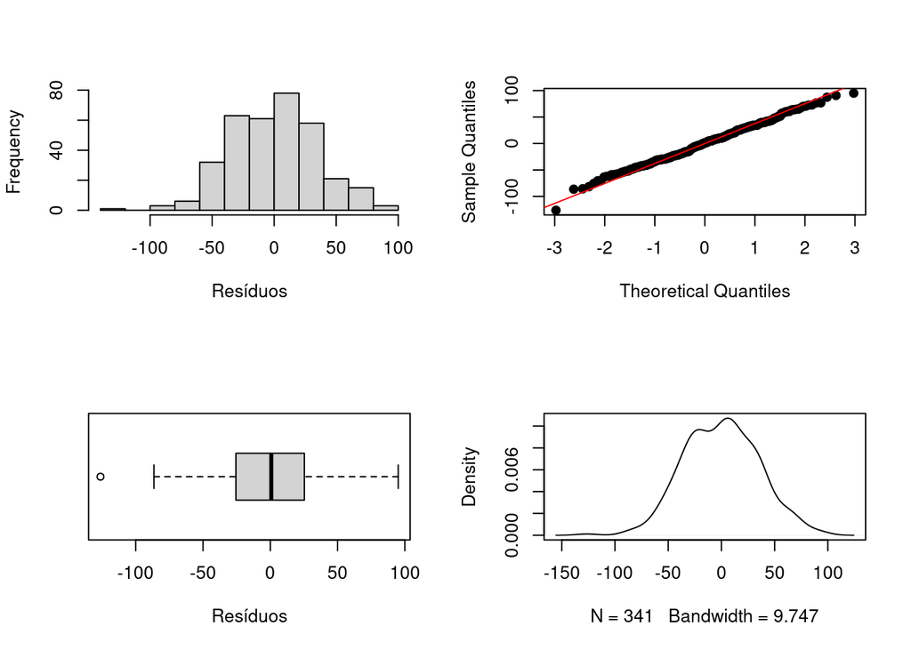

```r
# Analise gráfica
par(mfrow=c(2, 2))
hist(m.both$residuals, xlab="Resíduos", main="") # Histograma

qqnorm(m.both$residuals,pch=19, main = "") #QQNorm dos resíduos
qqline(m.both$residuals,col="red")

boxplot(m.both$residuals, xlab="Resíduos", horizontal = T) # Boxplot

plot(density(m.both$residuals), main = "") # Plot density
```

```r
# Teste de Shapiro-Wilk
shapiro.test(m.both$residuals)
```

```
##
##  Shapiro-Wilk normality test
##
## data:  m.both$residuals
## W = 0.99627, p-value = 0.6076
```

```r
# Teste de Kolmogorov-Smirnov
ks.test(m.both$residuals, "pnorm", mean=mean(m.both$residuals), sd=sd(m.both$residuals))
```

```
##
##  One-sample Kolmogorov-Smirnov test
##
## data:  m.both$residuals
## D = 0.039951, p-value = 0.6478
## alternative hypothesis: two-sided
```

**ii) Múlticolinearidade**

```r
library(car)
vif(m.both)
```

```
##           GVIF Df GVIF^(1/(2*Df))
## dtm   1.107938  1        1.052586
## epg5  3.200893  1        1.789104
## worms 3.283091  1        1.811930
## li    1.059252  2        1.014495
```

- Não foi observados colinearidade em nenhuma variável ($VIF's < 5$).

**iii) Homocedasticidade dos Resíduos**

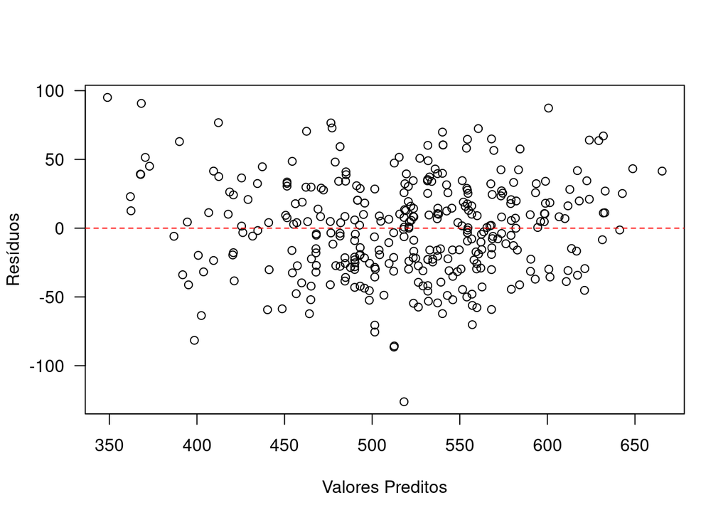

```r
## Grafico do predito x residuo
plot(m.both$fitted.values,m.both$residuals, xlab="Valores Preditos", ylab="Resíduos",main="", las=1)
abline(h=0, lwd=1, lty=2, col="red")
```

```r
# Teste de Breusch-Pagan
library(lmtest)
bptest(m.both)
```

```
##
##  studentized Breusch-Pagan test
##
## data:  m.both
## BP = 6.9167, df = 5, p-value = 0.2269
```

- Através do teste *Breusch-Pagan*, podemos dizer que os resíduos apresentam homocedasticidade $(p-value = 0,2269)$.

**Checagem do modelo de forma geral**

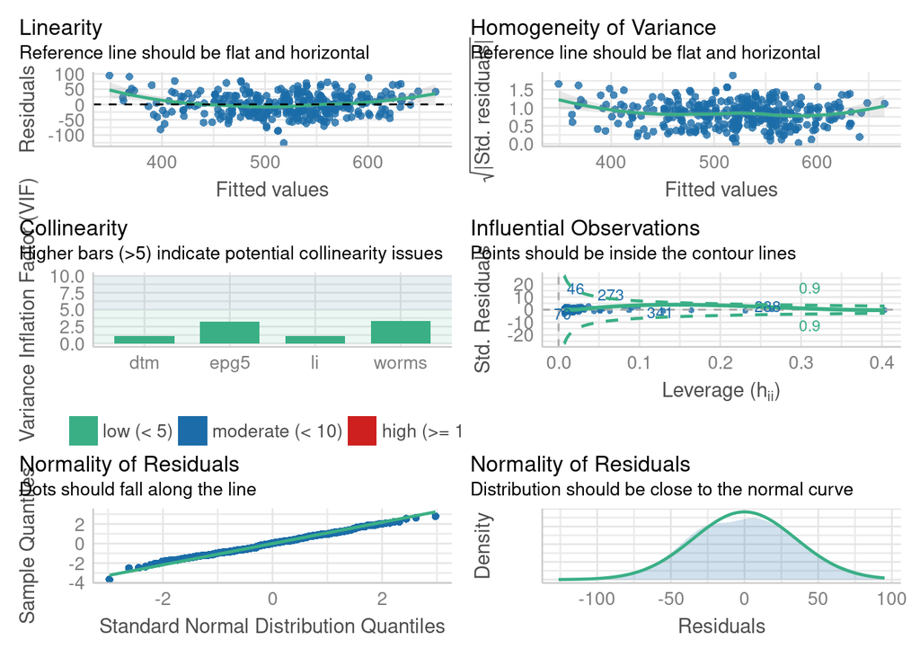

```r
check_model(m.both)
```

### 9. Caso haja necessidade, obtenha a melhor transformação para modelo. *Sugestão: Pode utilizar o método Box-Cox*;

- Em nosso exercício, aparentemente não existem evidências para fazer a trasformação dos dados uma vez que todos os pressumos foram atendidos. Mas de qualquer forma irei mostras como procederíamos com essa transformação caso houvesse necessidade de ser feita.

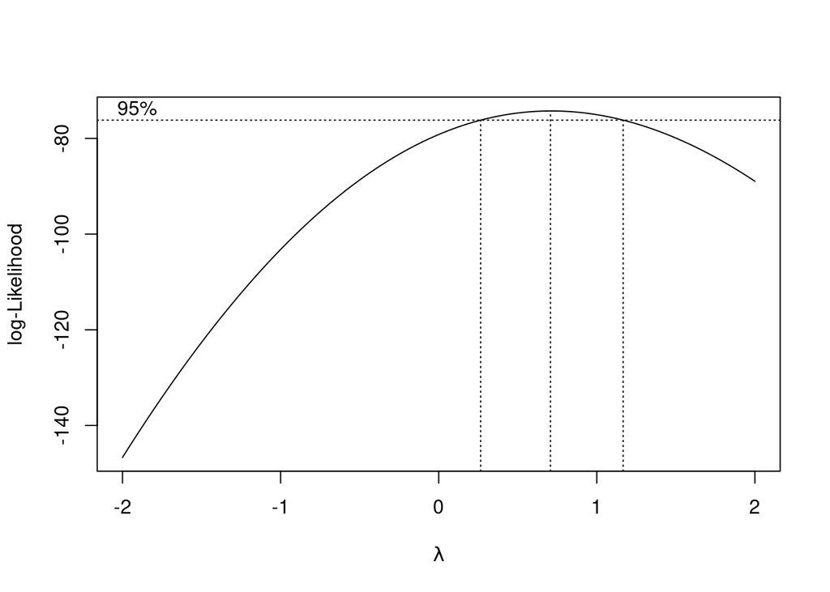

```r
library(MASS)

# Transformação boxcox
boxcox(m.both)

# Encontrando o lambda
bc <- boxcox(m.both)
```

```r
lambda <- bc$x[which.max(bc$y)]
lambda
```

```
## [1] 0.7070707
```

- Aplicando a Transformação de Box-Cox obtemos um valor de 0.707` que maximiza a log-verossimilhança para a transformação realizada.

```r
# Aplicação da transformacao boxcox em Y
banco$adg.t <- (banco$adg^(lambda)- 1)/lambda

# Ajuste do modelo com variável transformada
m.both2 <- lm(adg.t ~ dtm + epg5 + worms + li, data=banco)
summary(m.both2)
```

```
##
## Call:
## lm(formula = adg.t ~ dtm + epg5 + worms + li, data = banco)
##
## Residuals:
##      Min       1Q   Median       3Q      Max
## -20.7876  -3.9558   0.2482   3.9412  15.3234
##
## Coefficients:
##               Estimate Std. Error t value Pr(>|t|)
## (Intercept) 202.282143   2.928536  69.073   <2e-16 ***
## dtm          -0.448105   0.014339 -31.251   <2e-16 ***
## epg5         -0.003417   0.001852  -1.845   0.0659 .
## worms         0.097707   0.055814   1.751   0.0809 .
## liSuave      -1.795598   0.861543  -2.084   0.0379 *
## liSevera     -1.776397   0.881157  -2.016   0.0446 *
## ---
## Signif. codes:  0 '***' 0.001 '**' 0.01 '*' 0.05 '.' 0.1 ' ' 1
##
## Residual standard error: 5.613 on 335 degrees of freedom
## Multiple R-squared:  0.7613, Adjusted R-squared:  0.7578
## F-statistic: 213.7 on 5 and 335 DF,  p-value: < 2.2e-16
```

### 10. Se foi feito o item 9, ajuste uma regressão linear com os valores transformados de Y. Faça a análise dos resíduos. Houve diferença em relação ao modelo ajustado com a variável original ?

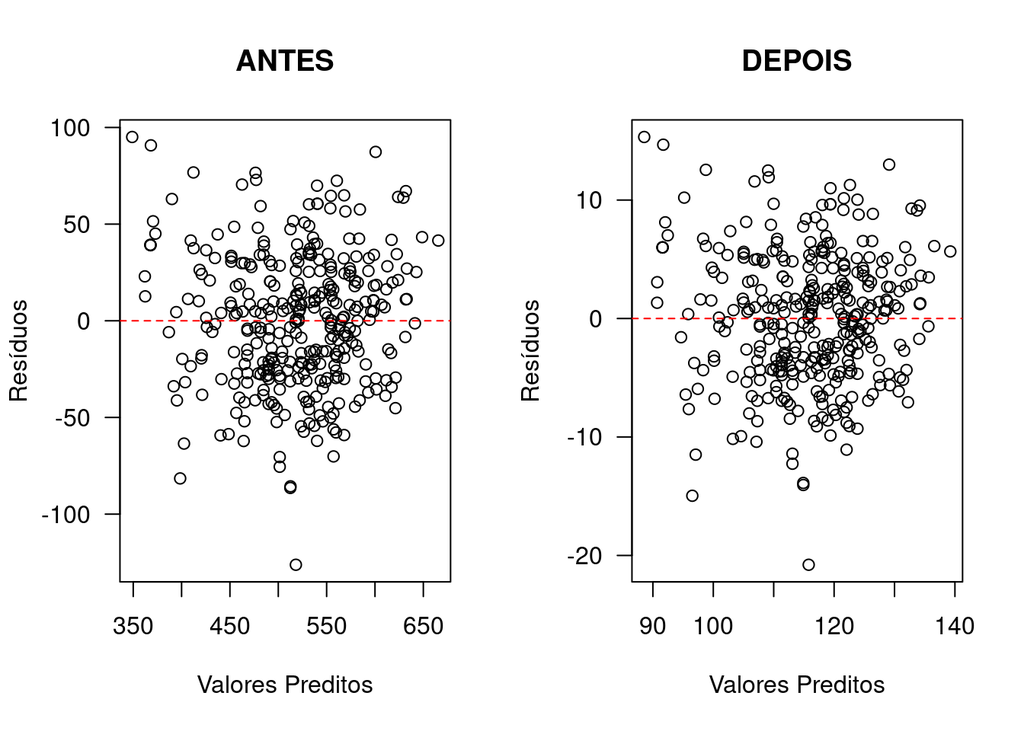

```r
# Comparação do gráfico predito vs resíduos antes e depois da transformação
par(mfrow=c(1,2))
plot(m.both$fitted.values, m.both$residuals, xlab="Valores Preditos", ylab="Resíduos", main="ANTES", las=1)
abline(h=0, lwd=1, lty=2, col="red")

plot(m.both2$fitted.values, m.both2$residuals,xlab="Valores Preditos", ylab="Resíduos", main="DEPOIS", las=1)
abline(h=0, lwd=1, lty=2, col="red")
```

```r
# Teste de Breusch-Pagan
bptest(m.both2)
```

```
##
##  studentized Breusch-Pagan test
##
## data:  m.both2
## BP = 11.167, df = 5, p-value = 0.04816
```

#### Checagem do modelo de forma geral

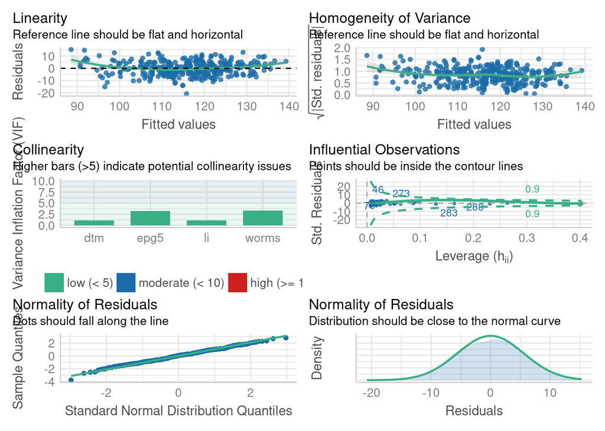

```r
check_model(m.both2)
```